# Week 1 seminar

Joshua Loftus

## Repeating the gapminder analysis

After running `library(gapminder)` you can access the dataset. Try typing `View(gapminder)` in the Console window below.

#### Create a `gapminder` scatterplot (`geom_point`) using data from the year 2002

First create an object with the right subset of data.

(hint: remember the `filter` function)

```r
gm2002 <- gapminder %>%
  filter(year == 2002)
```

Now use this data to create the scatterplot.

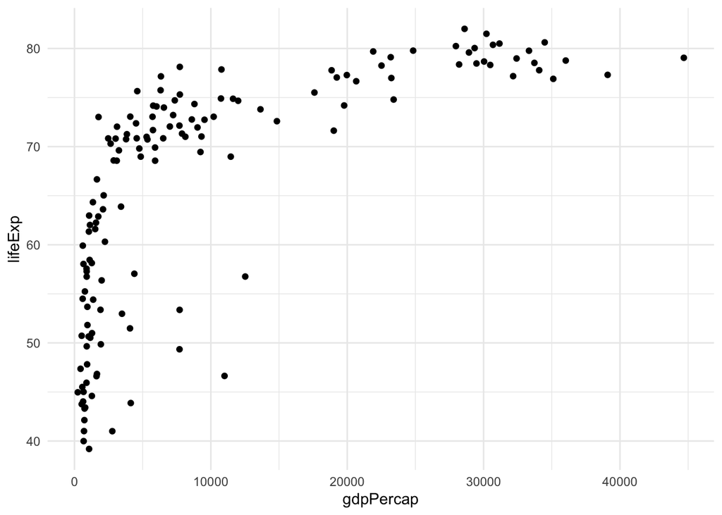

```r
gm_scatterplot <-
  ggplot(gm2002,
         aes(x = gdpPercap, y = lifeExp)) +
  geom_point()
gm_scatterplot
```

#### Create an `lm` model to predict `lifeExp` from `gdpPercap`

```r
model_lm <- lm(lifeExp ~ gdpPercap, data = gm2002)
predictions_lm <- augment(model_lm)
```

#### Create a `loess` model to do the same

```r
model_loess <- loess(lifeExp ~ gdpPercap, span = .75, data = gm2002)
predictions_loess <- augment(model_loess)
```

#### Plot showing the two models

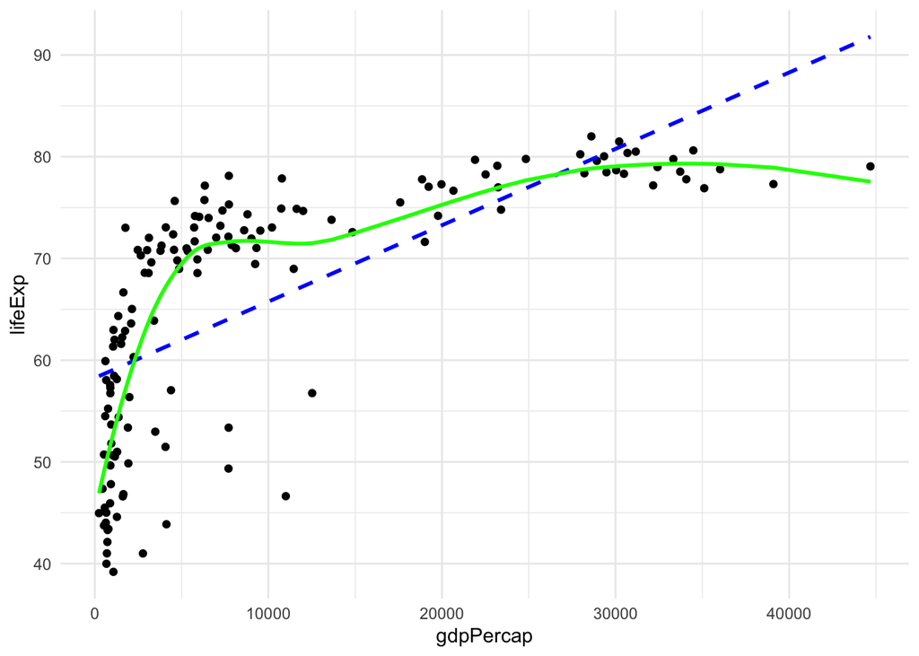

```r
gm_scatterplot +
  geom_line(data = predictions_lm, size = 1,
            color = "blue",
            linetype = "dashed",
            aes(x = gdpPercap, y = .fitted)) +
  geom_line(data = predictions_loess, size = 1,
            color = "green",
            aes(x = gdpPercap, y = .fitted))
```

Now try changing `span` in the `loess()` function to some other number (strictly) between 0 and 1, and re-run the code chunks. First re-run the code chunk that fits the model with `loess()`, then re-run the chunk that plots the predictions. Observe how the fitted curve is different.

#### Compute the mean square of `residuals()` of each model.

```r
mean(residuals(model_lm)^2)
```

```
## [1] 80.11716
```

```r
mean(residuals(model_loess)^2)
```

```
## [1] 45.21583
```

Which model is better? Why?

### Predicting on new data

Models are supposed to capture/use structure in the data that corresponds to structure in the real world. And if the real world isn’t misbehaving, that structure should be somewhat stable.

For example, suppose the relationship changed dramatically from one time period to another time period. Then it would be less useful/interesting to have a model fit on data at one time period, because the same model might have a poor fit on data from a different time period.

Let’s explore this with our `gapminder` models

#### Predictions on different years

Create a dataset for the year 1997

```r
gm1997 <- gapminder %>% filter(year == 1997)
```

Get predictions for 1997 from both models by predicting with the `newdata` argument

```r
lm_predict1997 <- augment(model_lm, newdata = gm1997)
loess_predict1997 <- augment(model_loess, newdata = gm1997)
```

#### Check MSE

```r
lm_predict1997 |>
  summarize(MSE = mean(.resid^2))
```

```
## # A tibble: 1 × 1
##     MSE
##   <dbl>
## 1  67.2
```

```r
loess_predict1997 |>
  summarize(MSE = mean(.resid^2))
```

```
## # A tibble: 1 × 1
##     MSE
##   <dbl>
## 1  31.6
```

**Question**: Is it surprising which model does better? Why or why not?

The more complex, `loess` model performs better than the linear model even when tested on different data. Apparently the association between `gdpPercap` and `lifeExp` is fairly stable over time.

## Simulation

### Generate data from a non-linear function

Choose a function. Be creative! Type `?sqrt` in the Console. Also try `?log` and `?sin`.

```r
f <- function(x) x^2 # change this
```

#### Data generating process

Come back here, change things, and re-run the code chunks below to experiment.

Type `?Distributions` in the Console to see other random variables you can choose from. The function name starting with `r` generates a random sample, e.g. `rexp` generates a sample from an exponential random variable.

```r
simulate_data <- function(n) {
  x <- runif(n, min = 0, max = 3) # change
  errors <- rnorm(n, sd = 1) # change
  y <- f(x) + errors
  data.frame(x = x, y = y)
}
```

Generate and plot data

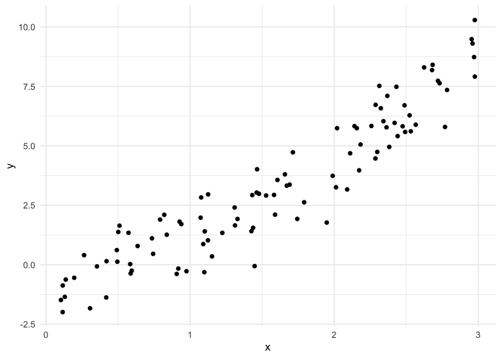

```r
n <- 100
sim_data <- simulate_data(n)
sim_plot <- ggplot(sim_data, aes(x = x, y = y)) +
  geom_point()
sim_plot
```

#### Fit `lm` and `loess` models to the simulated data and plot them

(Hint: copy and paste your earlier code, change `gm2002` and other variable names)

```r
model_sim_lm <- lm(y ~ x, data = sim_data)
predictions_sim_lm <- augment(model_sim_lm)
model_sim_loess <- loess(y ~ x, span = .75, data = sim_data)
predictions_sim_loess <- augment(model_sim_loess)
```

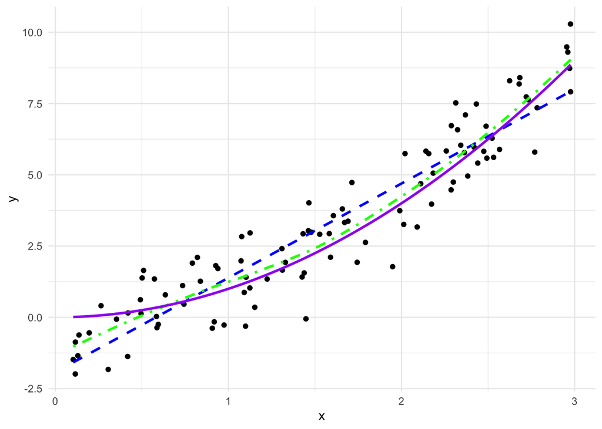

```r
sim_plot +
  geom_line(data = predictions_sim_lm, size = 1,
            color = "blue",
            linetype = "dashed",
            aes(x = x, y = .fitted)) +
  geom_line(data = predictions_sim_loess, size = 1,
            color = "green",
            linetype = "dotdash",
            aes(x = x, y = .fitted)) +
  geom_function(fun = f, color = "purple", size = 1)
```

```r
coef(model_sim_lm)
```

```
## (Intercept)           x
##   -1.924262    3.309123
```

```r
coef(model_sim_lm)[2]
```

```
##        x
## 3.309123
```

**Question**: How is this slope related to the true function `f`?

**Answer**: If the true model is linear then we could estimate the true slope. But if the true model is not linear, we may be estimating something only weakly related to the true relationship, like a weighted average of the slopes over the range of `x`.

### Sampling distribution of an estimator

```r
n_iters <- 5
simulate_slope <- function(n) {
  new_data <- simulate_data(n)
  new_model <- lm(y ~ x, new_data)
  coef(new_model)[2]
}
replicate(n_iters, simulate_slope(n))
```

```
##        x        x        x        x        x
## 2.782417 2.922220 2.929165 3.071938 2.948885
```

#### Histogram of many estimates

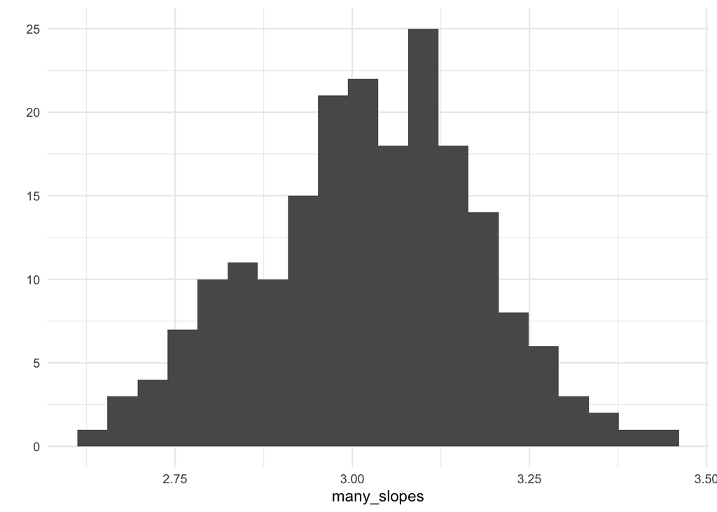

```r
n_iters <- 200
many_slopes <- replicate(n_iters, simulate_slope(n))
qplot(many_slopes, bins = 20)
```

**Question**: What do you notice about this distribution, and why?

**Answer**: It seems approximately normal. This happens because of the central limit theorem.

#### Experiment

Go back and change some inputs in previous code chunks and re-run all the chunks after that change.

Can you find anything that seems like it makes an important, qualitative difference in the conclusions?